# STAT340: Discussion 9: Multiple linear regression

Steven Hizmi

31 March, 2021

Link to source file

## Just for fun (1 min)

[figure not shown]

## Discuss together (5-10 min)

As an entire section, discuss these together:

1. What are the advantages of using multiple linear vs single linear regression, especially regarding interpreting the estimated coefficients?
2. What are the main assumptions you need to check for multiple linear regression that could suggest a poor fit, and how do these compare to simple linear regression?

## Exercise

Today we’re going to revisit the `mtcars` dataset and analyze it using multiple linear regression. Note this is a built-in dataset provided as part of the `datasets` package in `R`.

As usual, break off into groups of 3-4 students. In your group, nominate one person to share their screen.

### Background

Run `?(mtcars)` in the console (do NOT add it to this `Rmd` file) and briefly read the help page. Specifically, take note of the following:

1. What is the source of this data?
2. What is this dataset measuring? (i.e. what is the response variable?)
3. What predictors are available and what do they mean?

Feel free to also run `head(mtcars, 10)` or `View(mtcars)` to inspect the data frame briefly before moving on.

### Fitting

Uncomment the line below and finish it. Specifically, use `lm` to run a regression of `mpg` on all other predictors (an easy way to do this is to use `mpg ~ .` as the first argument). Make sure to also include `data = mtcars` as an argument or it won’t know where to get the variable names from.

```r
 lm.mtcars = lm(data = mtcars, mpg ~ .)
```

View a summary of the regression by uncommenting and running the line below

```r
 summary(lm.mtcars)
```

```
 #
 # Call:
 # lm(formula = mpg ~ ., data = mtcars)
 #
 # Residuals:
 #     Min      1Q  Median      3Q     Max
 # -3.4506 -1.6044 -0.1196  1.2193  4.6271
 #
 # Coefficients:
 #             Estimate Std. Error t value Pr(>|t|)
 # (Intercept) 12.30337   18.71788   0.657   0.5181
 # cyl         -0.11144    1.04502  -0.107   0.9161
 # disp         0.01334    0.01786   0.747   0.4635
 # hp          -0.02148    0.02177  -0.987   0.3350
 # drat         0.78711    1.63537   0.481   0.6353
 # wt          -3.71530    1.89441  -1.961   0.0633 .
 # qsec         0.82104    0.73084   1.123   0.2739
 # vs           0.31776    2.10451   0.151   0.8814
 # am           2.52023    2.05665   1.225   0.2340
 # gear         0.65541    1.49326   0.439   0.6652
 # carb        -0.19942    0.82875  -0.241   0.8122
 # ---
 # Signif. codes:  0 '***' 0.001 '**' 0.01 '*' 0.05 '.' 0.1 ' ' 1
 #
 # Residual standard error: 2.65 on 21 degrees of freedom
 # Multiple R-squared:  0.869,  Adjusted R-squared:  0.8066
 # F-statistic: 13.93 on 10 and 21 DF,  p-value: 3.793e-07
```

Briefly inspect the residuals plot by running `plot(lm.mtcars,which=1:2)` . What do you observe, and what does it mean?

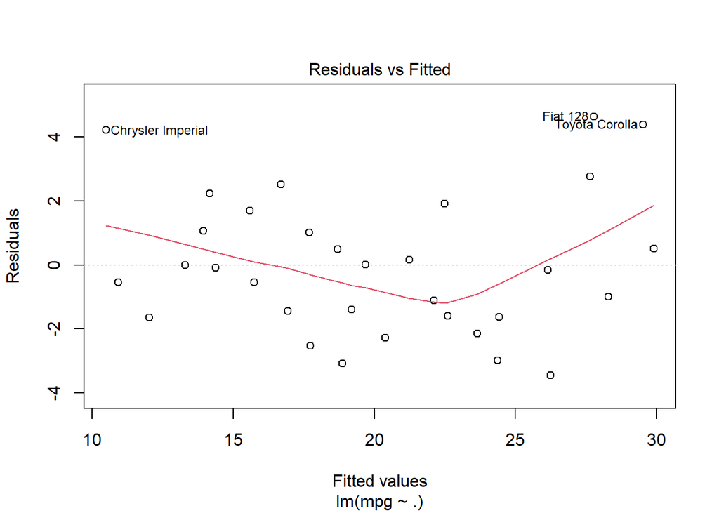

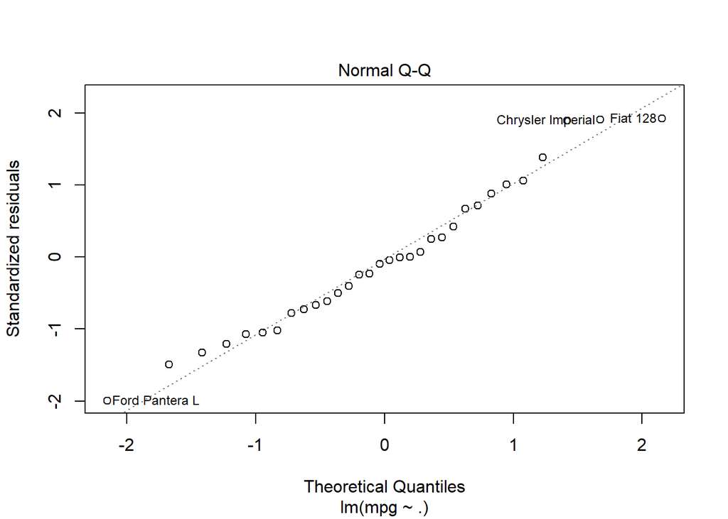

```r
plot(lm.mtcars,which=1:2)
```

### Interpretation

Uncomment the line below to get the estimated coefficients along with their standard errors.

```r
 summary(lm.mtcars)$coefficients
```

```
 #                Estimate  Std. Error    t value   Pr(>|t|)
 # (Intercept) 12.30337416 18.71788443  0.6573058 0.51812440
 # cyl         -0.11144048  1.04502336 -0.1066392 0.91608738
 # disp         0.01333524  0.01785750  0.7467585 0.46348865
 # hp          -0.02148212  0.02176858 -0.9868407 0.33495531
 # drat         0.78711097  1.63537307  0.4813036 0.63527790
 # wt          -3.71530393  1.89441430 -1.9611887 0.06325215
 # qsec         0.82104075  0.73084480  1.1234133 0.27394127
 # vs           0.31776281  2.10450861  0.1509915 0.88142347
 # am           2.52022689  2.05665055  1.2254035 0.23398971
 # gear         0.65541302  1.49325996  0.4389142 0.66520643
 # carb        -0.19941925  0.82875250 -0.2406258 0.81217871
```

Give an interpretation of the estimate and standard error for one of these predictor variables. Be careful in your wording of the interpretation.

> *The estimate gives us the expected change in the response due to a change in the X. The standard error is the standard error of the estimate which is useful when constructing confidence intervals.*

What does the intercept here mean? (Except for special situations, we generally don’t care much about the intercept, but you should still understand what it means.)

> *The intercept is the expected mean value of Y when all X = 0.*

Karl doesn’t like the R² statistic, but what is the R² for this model? (Hint: look at the output of `summary`) Give an interpretation of this value.

```r
summary(lm.mtcars)$r.squared
```

```
 # [1] 0.8690158
```

> *R squared measures how close the data is to the fitted regression line. If R squared was 1, then that indicates that the model explains all the variability of the response data around the mean.*

Briefly read about the [adjusted R² here](https://www.statisticshowto.com/probability-and-statistics/statistics-definitions/adjusted-r2/). What is the adjusted R² of this model and how does this differ from the normal R² value? (Hint: again, look at the output of `summary`).

```r
summary(lm.mtcars)$adj.r.squared
```

```
 # [1] 0.8066423
```

> *Adjusted R-squared is the same as R-squared, except it adjusts the statistic based on the number of independent variables in the model. It shows whether adding additional predictors improve a reggresion or not.*

Generate $95\%$ confidence intervals for the coefficients using the `confint` function. Give an interpretation of these confidence intervals.

```r
confint(lm.mtcars, level = 0.95)
```

```
 #                    2.5 %      97.5 %
 # (Intercept) -26.62259745 51.22934576
 # cyl          -2.28468553  2.06180457
 # disp         -0.02380146  0.05047194
 # hp           -0.06675236  0.02378812
 # drat         -2.61383350  4.18805545
 # wt           -7.65495413  0.22434628
 # qsec         -0.69883421  2.34091571
 # vs           -4.05880242  4.69432805
 # am           -1.75681208  6.79726585
 # gear         -2.44999107  3.76081711
 # carb         -1.92290442  1.52406591
```

> _ 95% of any new data of each X should respectively fall within the interval._

### Prediction

According to the model, what mileage would I expect on average with a car that has 6 cylinders, 200 displacement, 120 horsepower, 3.4 rear axle ratio, 2500 pounds, 17.5 1/4 mile time, a straight engine, automatic transmission, 4 forward gears, and 3 carburetors? (Be careful of your units and how you denote the engine and transmission variables. Again, the help page `?mtcars` may be very helpful here.)

```r
sample <- data.frame(cyl=6,disp=200,hp=120,drat=3.4,wt=2500,qsec=17.5,vs=1,am=0,gear=4,carb=3)
predict(lm.mtcars,sample)
```

```
 #        1
 # -9257.15
```

## Submission

As usual, make sure the names of everyone who worked on this with you is included in the header of this document. Then, knit this document and submit both this file and the HTML output on Canvas under Assignments ⇒ Discussion 7.